# Visualization (Exploring variation)

Peter Ganong and Maggie Shi

January 25, 2026

# Introduction

## Skills hopefully acquired at the end of lecture

Take a single variable in a dataset.

Visualize to learn more about it. Key cases of interest: * Categorical variables (in lecture 2 we called these `N`/`O`) * Continuous variables (in lecture 2 we called these `Q`) * Exploring typical values * Exploring and dealing with unusual values

(Up next class: covariation with two variables)

## Roadmap of lecture

- Introduce three key ideas in data visualization
  - exploration vs. production
  - headline vs. sub-messages
  - iteration
- introduce datasets for this lecture
- Categorical variables (in lecture 2 we called these `N`/`O`)
- Continuous variables (in lecture 2 we called these `Q`)
  - Exploring typical values
  - Exploring and dealing with unusual values

## What is exploratory data analysis?

Data visualization has two distinct goals

1. **exploration** for you to *learn* as much as possible
2. **production** for you to *teach* someone else what you think the key lessons are

## Exploration vs. production

- When you are in exploration mode, you will look at lots of patterns and your brain filters out the noise
- Production mode is like putting a cone on your dog.
- You are deliberately limiting the reader’s field of vision such that they see the key messages from the plot *and avoid too many distractions*

## “A Sunday on La Grande Jatte” by Seurat

[figure not shown]

## “A Sunday on La Grande Jatte” by Seurat

[figure not shown]

## Headline vs submessages

- **Headline** is what you see first when you look at the painting or you look at the plot.
- **Submessages** are what you see later, on closer inspection
- Often, the most interesting patterns in the data are ones that you don’t see right away when you make the very first plot.

## Iterating on plot design

> “Make dozens of plots”

Quoctrung Bui, former 30538 guest lecturer and former Harris data viz instructor

## Iterating on plot design

What does he mean?

- The first plot you make will never be the one you should show
- As you are generating graphs for yourself in exploration mode, you will produce many candidates that could end up being used in production mode
- As a rule of thumb, you should try out at least three different plotting concepts (marks)
- Within each concept, you will need to try out several different encodings

## Summary:

1. Decide if you are trying to explore the data or produce a plot for someone else
2. For any given plot, look closely (like Seurat) beyond just the headline
3. Iterate

# Intro to data

## Introduction to data

- Most of our visualization lectures are based on the [University of Washington](https://idl.uw.edu/visualization-curriculum/) textbook, but the textbook doesn’t have enough material on exploratory data analysis. So we are supplementing with
  - [Data Visualization](https://r4ds.hadley.nz/data-visualize)
  - [Exploratory Data Analysis](https://r4ds.hadley.nz/EDA.html) material in the **R for Data Science** textbook (with the code translated to Altair)
- `diamonds`, `mpg` are from “Exploratory Data Analysis”
- `movies` (also used last lecture) is from the UW textbook
- `penguins` is from “Data Visualization”

# Categorical variables

## Categorical variables: roadmap

- introduce `diamonds`
- show table
- show bar graph

## introduce dataset `diamonds`

```python
import pandas as pd
from plotnine.data import diamonds
diamonds.shape
```

```
(53940, 10)
```

```python
diamonds.head()
```

|  | carat | cut | color | clarity | depth | table | price | x | y | z |
| --- | --- | --- | --- | --- | --- | --- | --- | --- | --- | --- |
| 0 | 0.23 | Ideal | E | SI2 | 61.5 | 55.0 | 326 | 3.95 | 3.98 | 2.43 |
| 1 | 0.21 | Premium | E | SI1 | 59.8 | 61.0 | 326 | 3.89 | 3.84 | 2.31 |
| 2 | 0.23 | Good | E | VS1 | 56.9 | 65.0 | 327 | 4.05 | 4.07 | 2.31 |
| 3 | 0.29 | Premium | I | VS2 | 62.4 | 58.0 | 334 | 4.20 | 4.23 | 2.63 |
| 4 | 0.31 | Good | J | SI2 | 63.3 | 58.0 | 335 | 4.34 | 4.35 | 2.75 |

## `diamonds` data dictionary

| Variable | Definition | Values |
| --- | --- | --- |
| `price` | price in USD | $326–$18,823 |
| `carat` | weight of diamond | 0.2-5.01 |
| `cut` | quality of the cut | Fair, Good, Very Good, Premium, Ideal |
| `color` | diamond color | D (best) to J (worst) |
| `clarity` | measure of how clear diamond is | I1 (worst), SI2, SI1, VS2, VS1, VVS2, VVS1, IF (best) |
| `x` | length in mm | 0-10.74 |
| `y` | width in mm | 0-58.9 |
| `z` | depth in mm | 0-31.8 |
| `depth` | $\frac{z}{ mean(x, y)}$ | 43-79 |
| `table` | width of top of diamond relative to widest point | 43-95 |

## Summarizing `cut` in a table

```python
diamonds_cut = diamonds.groupby('cut').size()
diamonds_cut
```

```
cut
Fair          1610
Good          4906
Very Good    12082
Premium      13791
Ideal        21551
dtype: int64
```

## Summarizing with a bar graph (code)

```python
#moves the index (`cut`) into a normal column so Altair can read it.
diamonds_cut = diamonds_cut.reset_index().rename(columns={0:'N diamonds'})

# extract ordering of `cut` as a Python list to use for sorting
cut_order = diamonds['cut'].cat.categories.tolist()

alt.Chart(diamonds_cut).mark_bar().encode(
    alt.X('cut:O', title = "Cut", sort=cut_order),
    alt.Y('N diamonds:Q', title = "Count")
).properties(width=640, height=360).configure_axis(
    labelFontSize=18,
    titleFontSize=20
)
```

**Note**: we have included syntax to modify graph properties here. Going forward our `.qmd` source code uses these throughout, but we will omit in the slides for the sake of space.

## Summarizing with a bar graph (plot)

[figure not shown]

## Categorical variables: summary

- This section is very brief because there’s basically only one good way to plot categorical variables with a small number of categories and this is it.
  - You can use `mark_point()` instead of `mark_bar()`, but overall, there’s a clear right answer about how to do this.
- We include this material mainly to foreshadow the fact that we will do a lot on categorical variables in the next lecture when we get to “Exploring Co-variation”

# Continuous Variables

## Continuous variables: roadmap

- Binning + histograms using `movies`
- Histograms and density plots using `penguins`
- Exploring carat size using `diamonds`

Remark: The skills are absolutely fundamental and so we will intentionally be a bit repetitive.

## Recall: `movies` dataset

```python
movies_url = 'https://cdn.jsdelivr.net/npm/vega-datasets@1/data/movies.json'
movies = pd.read_json(movies_url)
movies.head()
```

|  | Title | US_Gross | Worldwide_Gross | US_DVD_Sales | Production_Budget | Release_Date | MPAA_Rating | Running_Time_min | Distributor | Source | Major_Genre | Creative_Type | Director | Rotten_Tomatoes_Rating | IMDB_Rating | IMDB_Votes |
| --- | --- | --- | --- | --- | --- | --- | --- | --- | --- | --- | --- | --- | --- | --- | --- | --- |
| 0 | The Land Girls | 146083.0 | 146083.0 | NaN | 8000000.0 | Jun 12 1998 | R | NaN | Gramercy | None | None | None | None | NaN | 6.1 | 1071.0 |
| 1 | First Love, Last Rites | 10876.0 | 10876.0 | NaN | 300000.0 | Aug 07 1998 | R | NaN | Strand | None | Drama | None | None | NaN | 6.9 | 207.0 |
| 2 | I Married a Strange Person | 203134.0 | 203134.0 | NaN | 250000.0 | Aug 28 1998 | None | NaN | Lionsgate | None | Comedy | None | None | NaN | 6.8 | 865.0 |
| 3 | Let's Talk About Sex | 373615.0 | 373615.0 | NaN | 300000.0 | Sep 11 1998 | None | NaN | Fine Line | None | Comedy | None | None | 13.0 | NaN | NaN |
| 4 | Slam | 1009819.0 | 1087521.0 | NaN | 1000000.0 | Oct 09 1998 | R | NaN | Trimark | Original Screenplay | Drama | Contemporary Fiction | None | 62.0 | 3.4 | 165.0 |

## Histogram using `mark_bar()`

- **Rotten Tomatoes** ratings are determined by taking “thumbs up” and “thumbs down” judgments from film critics and calculating the percentage of positive reviews.
- This is a continuous measure, but we can bin it to create a **histogram** of frequencies

## Histogram using `mark_bar()`

```python
hist_rt = alt.Chart(movies_url).mark_bar().encode(
    alt.X('Rotten_Tomatoes_Rating:Q', bin=alt.BinParams(maxbins=20), title = "Rotten Tomatoes Rating (%)"),
    alt.Y('count():Q', title = "Count")
)
hist_rt
```

[figure not shown]

Discussion question: what are the headline and sub-messages?

## Histogram of IMDB ratings

**IMDB ratings** are formed by averaging scores (ranging from 1 to 10) provided by the site’s users.

```python
hist_imdb = alt.Chart(movies_url).mark_bar().encode(
    alt.X('IMDB_Rating:Q', bin=alt.BinParams(maxbins=20), title = "IMDB Ratings"),
    alt.Y('count():Q', title = "Count")
)
hist_imdb
```

[figure not shown]

## Side-by-side

```python
hist_rt | hist_imdb
```

[figure not shown]

Discussion question: compare the two ratings distributions. If *your goal for the headline of the graph is about differentiating between good and bad movies*, which rating is more informative?

## Introducing the `penguins` dataset

```python
url = ("https://raw.githubusercontent.com/mcnakhaee/palmerpenguins/master/palmerpenguins/data/penguins.csv")
penguins = pd.read_csv(url)
penguins.head()
```

|  | species | island | bill_length_mm | bill_depth_mm | flipper_length_mm | body_mass_g | sex | year |
| --- | --- | --- | --- | --- | --- | --- | --- | --- |
| 0 | Adelie | Torgersen | 39.1 | 18.7 | 181.0 | 3750.0 | male | 2007 |
| 1 | Adelie | Torgersen | 39.5 | 17.4 | 186.0 | 3800.0 | female | 2007 |
| 2 | Adelie | Torgersen | 40.3 | 18.0 | 195.0 | 3250.0 | female | 2007 |
| 3 | Adelie | Torgersen | NaN | NaN | NaN | NaN | NaN | 2007 |
| 4 | Adelie | Torgersen | 36.7 | 19.3 | 193.0 | 3450.0 | female | 2007 |

## Histogram with steps of 200

- We previously picked the maximum number of equally-spaced bins (`BinParams(maxbins=20)`) and let `altair` choose “nice”-looking bin widths for the histogram
- Alternatively, we can manually control the bin width using `step`

## Histogram with steps of 200

```python
alt.Chart(penguins).mark_bar().encode(
    alt.X('body_mass_g:Q', bin=alt.BinParams(step=200), title = "Body Mass (g)"),
    alt.Y('count():Q', title = "Count")
)
```

[figure not shown]

## Histogram `step` parameter

`step=20` vs. `step=200` vs, `step=2000`

[figure not shown]

Discussion question: what headline message(s) come from each `step` choice? Which do you prefer?

## Density plot

An alternative to a histogram for exploring frequency in continuous variable: density plot using `transform_density`

```python
alt.Chart(penguins).transform_density(
    'body_mass_g',
    as_=['body_mass_g2', 'density']
).mark_area().encode(
    alt.X('body_mass_g2:Q', title = "Body Mass (g)"),
    alt.Y('density:Q', title = "Density")
)
```

[figure not shown]

## Back to diamonds, focus on `carat`

```python
alt.data_transformers.disable_max_rows()  #disable 5k max rows

alt.Chart(diamonds).mark_bar().encode(
    alt.X('carat', bin=alt.Bin(maxbins=10), title = "Carat"),
    alt.Y('count()', title = "Count")
)
```

[figure not shown]

First plot iteration reveals most of sample is < 2

## Histogram of `carat`

```python
diamonds_small = diamonds.loc[diamonds['carat'] < 2.1]

alt.Chart(diamonds_small).mark_bar().encode(
    alt.X('carat', bin=alt.BinParams(step=0.2), title = "Carat"),
    alt.Y('count()', title = "Count")
)
```

[figure not shown]

Second plot iteration reveals count is not *entirely* decreasing in carat

## In-class exercise: histogram of `carat`

```python
alt.Chart(diamonds_small).mark_bar().encode(
    alt.X('carat', bin=alt.BinParams(step=0.02), title = "Carat"),
    alt.Y('count()', title = "Count"))
```

[interactive chart not shown]

Discussion questions

1. What is the headline of the 3rd plot iteration? Submessages?
2. What questions does it raise?

## Typical continuous variables: summary

- Main tool to explore uni-dimensional continuous variables: histograms
- Varying the bin widths can reveal different patterns

# Continuous variables: unusual values

## Unusual continuous variables: roadmap

- case study: `y` dimension in diamonds
  - explore some unusual values
  - three options for handling unusual values

## `diamonds`: identify unusual `y` values

First pass to examine for unusual values: summary statistics

```python
diamonds['y'].describe()
```

```
count    53940.000000
mean         5.734526
std          1.142135
min          0.000000
25%          4.720000
50%          5.710000
75%          6.540000
max         58.900000
Name: y, dtype: float64
```

## `diamonds`: examine unusual `y` values

```python
diamonds.loc[(diamonds['y'] < 3) ]
```

|  | carat | cut | color | clarity | depth | table | price | x | y | z |
| --- | --- | --- | --- | --- | --- | --- | --- | --- | --- | --- |
| 11963 | 1.00 | Very Good | H | VS2 | 63.3 | 53.0 | 5139 | 0.0 | 0.0 | 0.0 |
| 15951 | 1.14 | Fair | G | VS1 | 57.5 | 67.0 | 6381 | 0.0 | 0.0 | 0.0 |
| 24520 | 1.56 | Ideal | G | VS2 | 62.2 | 54.0 | 12800 | 0.0 | 0.0 | 0.0 |
| 26243 | 1.20 | Premium | D | VVS1 | 62.1 | 59.0 | 15686 | 0.0 | 0.0 | 0.0 |
| 27429 | 2.25 | Premium | H | SI2 | 62.8 | 59.0 | 18034 | 0.0 | 0.0 | 0.0 |
| 49556 | 0.71 | Good | F | SI2 | 64.1 | 60.0 | 2130 | 0.0 | 0.0 | 0.0 |
| 49557 | 0.71 | Good | F | SI2 | 64.1 | 60.0 | 2130 | 0.0 | 0.0 | 0.0 |

## `diamonds`: examine unusual `y` values

```python
diamonds.loc[(diamonds['y'] > 20)]
```

|  | carat | cut | color | clarity | depth | table | price | x | y | z |
| --- | --- | --- | --- | --- | --- | --- | --- | --- | --- | --- |
| 24067 | 2.00 | Premium | H | SI2 | 58.9 | 57.0 | 12210 | 8.09 | 58.9 | 8.06 |
| 49189 | 0.51 | Ideal | E | VS1 | 61.8 | 55.0 | 2075 | 5.15 | 31.8 | 5.12 |

## `diamonds`: compare to 10 random obs

```python
diamonds.sample(n=10)
```

|  | carat | cut | color | clarity | depth | table | price | x | y | z |
| --- | --- | --- | --- | --- | --- | --- | --- | --- | --- | --- |
| 46051 | 0.54 | Ideal | E | VS1 | 62.6 | 55.0 | 1732 | 5.20 | 5.22 | 3.26 |
| 52198 | 0.70 | Premium | G | VS2 | 61.8 | 60.0 | 2479 | 5.67 | 5.63 | 3.49 |
| 15736 | 1.01 | Ideal | G | VS2 | 62.0 | 54.9 | 6295 | 6.41 | 6.44 | 3.99 |
| 39959 | 0.33 | Premium | D | SI2 | 61.6 | 59.0 | 492 | 4.41 | 4.42 | 2.72 |
| 17562 | 1.00 | Premium | F | VS2 | 59.0 | 59.0 | 7072 | 6.54 | 6.51 | 3.85 |
| 34918 | 0.34 | Premium | F | VS2 | 61.2 | 59.0 | 880 | 4.52 | 4.47 | 2.75 |
| 31252 | 0.46 | Ideal | F | SI2 | 61.5 | 54.0 | 758 | 4.98 | 5.01 | 3.07 |
| 47113 | 0.65 | Very Good | I | VVS2 | 61.3 | 59.3 | 1828 | 5.52 | 5.59 | 3.40 |
| 48830 | 0.70 | Good | H | SI1 | 63.3 | 60.0 | 2029 | 5.57 | 5.65 | 3.55 |
| 3071 | 0.80 | Premium | D | SI1 | 61.7 | 58.0 | 3312 | 5.96 | 5.93 | 3.67 |

## What to do with unusual values?

1. Drop row
2. Code value to `NA`
3. Winsorize value

## Option 1: drop rows

```python
diamonds_clean = diamonds.loc[(diamonds['y'] >= 3) | (diamonds['y'] <= 20)]
diamonds_clean
```

|  | carat | cut | color | clarity | depth | table | price | x | y | z |
| --- | --- | --- | --- | --- | --- | --- | --- | --- | --- | --- |
| 0 | 0.23 | Ideal | E | SI2 | 61.5 | 55.0 | 326 | 3.95 | 3.98 | 2.43 |
| 1 | 0.21 | Premium | E | SI1 | 59.8 | 61.0 | 326 | 3.89 | 3.84 | 2.31 |
| 2 | 0.23 | Good | E | VS1 | 56.9 | 65.0 | 327 | 4.05 | 4.07 | 2.31 |
| 3 | 0.29 | Premium | I | VS2 | 62.4 | 58.0 | 334 | 4.20 | 4.23 | 2.63 |
| 4 | 0.31 | Good | J | SI2 | 63.3 | 58.0 | 335 | 4.34 | 4.35 | 2.75 |
| ... | ... | ... | ... | ... | ... | ... | ... | ... | ... | ... |
| 53935 | 0.72 | Ideal | D | SI1 | 60.8 | 57.0 | 2757 | 5.75 | 5.76 | 3.50 |
| 53936 | 0.72 | Good | D | SI1 | 63.1 | 55.0 | 2757 | 5.69 | 5.75 | 3.61 |
| 53937 | 0.70 | Very Good | D | SI1 | 62.8 | 60.0 | 2757 | 5.66 | 5.68 | 3.56 |
| 53938 | 0.86 | Premium | H | SI2 | 61.0 | 58.0 | 2757 | 6.15 | 6.12 | 3.74 |
| 53939 | 0.75 | Ideal | D | SI2 | 62.2 | 55.0 | 2757 | 5.83 | 5.87 | 3.64 |

53940 rows × 10 columns

## Option 2: recode to missing

```python
diamonds_missing = diamonds.copy()
diamonds_missing['y'] = np.where((diamonds_missing['y'] < 3) |
     (diamonds_missing['y'] > 20),
     np.nan, diamonds_missing['y'])
diamonds_missing[diamonds_missing['y'].isna()]
```

|  | carat | cut | color | clarity | depth | table | price | x | y | z |
| --- | --- | --- | --- | --- | --- | --- | --- | --- | --- | --- |
| 11963 | 1.00 | Very Good | H | VS2 | 63.3 | 53.0 | 5139 | 0.00 | NaN | 0.00 |
| 15951 | 1.14 | Fair | G | VS1 | 57.5 | 67.0 | 6381 | 0.00 | NaN | 0.00 |
| 24067 | 2.00 | Premium | H | SI2 | 58.9 | 57.0 | 12210 | 8.09 | NaN | 8.06 |
| 24520 | 1.56 | Ideal | G | VS2 | 62.2 | 54.0 | 12800 | 0.00 | NaN | 0.00 |
| 26243 | 1.20 | Premium | D | VVS1 | 62.1 | 59.0 | 15686 | 0.00 | NaN | 0.00 |
| 27429 | 2.25 | Premium | H | SI2 | 62.8 | 59.0 | 18034 | 0.00 | NaN | 0.00 |
| 49189 | 0.51 | Ideal | E | VS1 | 61.8 | 55.0 | 2075 | 5.15 | NaN | 5.12 |
| 49556 | 0.71 | Good | F | SI2 | 64.1 | 60.0 | 2130 | 0.00 | NaN | 0.00 |
| 49557 | 0.71 | Good | F | SI2 | 64.1 | 60.0 | 2130 | 0.00 | NaN | 0.00 |

## Option 3: winsorize

Winsorizing re-codes outliers to a numeric value, keeping them in the data.

To winsorize at 1 percent:

- Replace anything less than the 1st percentile with the 1st percentile
- Replace anything more than the 99th percentile with the 99th percentile

## Option 3: winsorize

```python
diamonds_winsor = diamonds.copy()
pctile01 = diamonds_winsor['y'].quantile(0.01)
pctile99 = diamonds_winsor['y'].quantile(0.99)

print(f"1st Percentile: {pctile01}")
print(f"99th Percentile: {pctile99}")
```

```
1st Percentile: 4.04
99th Percentile: 8.34
```

## Option 3: winsorize

```python
diamonds_winsor['y_winsor'] = np.where(diamonds_winsor['y'] < pctile01, pctile01,
                                np.where(diamonds_winsor['y'] > pctile99, pctile99,
                                diamonds_winsor['y']))
diamonds_winsor
```

|  | carat | cut | color | clarity | depth | table | price | x | y | z | y_winsor |
| --- | --- | --- | --- | --- | --- | --- | --- | --- | --- | --- | --- |
| 0 | 0.23 | Ideal | E | SI2 | 61.5 | 55.0 | 326 | 3.95 | 3.98 | 2.43 | 4.04 |
| 1 | 0.21 | Premium | E | SI1 | 59.8 | 61.0 | 326 | 3.89 | 3.84 | 2.31 | 4.04 |
| 2 | 0.23 | Good | E | VS1 | 56.9 | 65.0 | 327 | 4.05 | 4.07 | 2.31 | 4.07 |
| 3 | 0.29 | Premium | I | VS2 | 62.4 | 58.0 | 334 | 4.20 | 4.23 | 2.63 | 4.23 |
| 4 | 0.31 | Good | J | SI2 | 63.3 | 58.0 | 335 | 4.34 | 4.35 | 2.75 | 4.35 |
| ... | ... | ... | ... | ... | ... | ... | ... | ... | ... | ... | ... |
| 53935 | 0.72 | Ideal | D | SI1 | 60.8 | 57.0 | 2757 | 5.75 | 5.76 | 3.50 | 5.76 |
| 53936 | 0.72 | Good | D | SI1 | 63.1 | 55.0 | 2757 | 5.69 | 5.75 | 3.61 | 5.75 |
| 53937 | 0.70 | Very Good | D | SI1 | 62.8 | 60.0 | 2757 | 5.66 | 5.68 | 3.56 | 5.68 |
| 53938 | 0.86 | Premium | H | SI2 | 61.0 | 58.0 | 2757 | 6.15 | 6.12 | 3.74 | 6.12 |
| 53939 | 0.75 | Ideal | D | SI2 | 62.2 | 55.0 | 2757 | 5.83 | 5.87 | 3.64 | 5.87 |

53940 rows × 11 columns

## When might you winsorize?

An example from [Earnings Instability](https://bpb-us-w2.wpmucdn.com/voices.uchicago.edu/dist/1/801/files/2025/09/2025-08-20-earnings-instability.pdf) paper by Ganong and coauthors.

The paper is trying to quantify how much earnings change from month to month for the typical US worker.

Consider the following fake data (next slide)

## Toy winsorization example

Suppose we have observations for earnings changes. 99% of the data follows a normal distribution with std. dev. 0.2 and 1% of the data is extremely large changes

| last month ($) | this month ($) | % change | \|% change \| |
| --- | --- | --- | --- |
| 600 | 600 | 0% | 0% |
| 600 | 570 | -5% | 5% |
| 600 | 540 | -10% | 10% |
| 600 | 630 | 5% | 5% |
| … |  |  |  |
| (99% of sample) |  |  |  |
| … |  |  |  |
| 600 | 300 | -50% | 50% |
| 6000 | 300 | -95% | 95% |
| 300 | 600 | 100% | 100% |
| 300 | 6000 | 1900% | 1900% |

What is the standard deviation of the % change in earnings?

| assumption | SD |
| --- | --- |
| do not winsorize | 97.2% |
| winsorize at 50% | 20.5% |

Illustrative calculation [here](https://chatgpt.com/share/696a7266-2ecc-8008-a603-767109b02a2f)

When else is this useful? Income data, test scores, stock returns.

## Real-world winsorization example

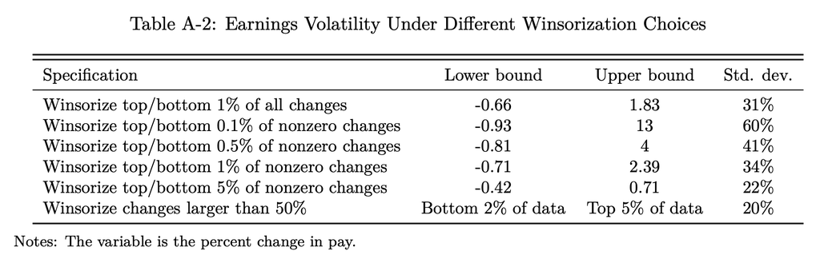

Source: Table A-2 from [Earnings Instability](https://bpb-us-w2.wpmucdn.com/voices.uchicago.edu/dist/1/801/files/2025/09/2025-08-20-earnings-instability.pdf) paper

## Pros + cons of each option

- **Dropping the observation**
  - Does not manipulate the data values
  - But can’t use that observation *at all* in your analysis
- **Recoding to missing**
  - Manipulates the data values
  - Allows you to use that observation – just not *that variable* – in your analysis
- **Winsorizing**
  - Manipulates the data values
  - Allows you to use that observation + that variable in your analysis

## `diamonds`: what would you do?

- What would you do where `x`, `y`, and `z` are all 0?
- What would you do where `y > 20`?

## `diamonds`: what would we do?

There is often not a “right” answer or you won’t know the answer without talking to a data provider.

Our best guesses:

- Rows where `x`, `y`, and `z` are all zero: set to `NA`
- Rows where `y > 20`: winsorize? (hard to know for sure…)

## Unusual continuous values: summary

| Problem | Action |
| --- | --- |
| Erroneous row | drop row |
| Erroneous cell | set to NA or winsorize |

**How do I decide which problem I have?** Examine unusual values in context of other columns (same row) and other rows (same columns).

**How do I decide whether to set to `NA` or winsorize?** Ideally, ask your data provider what’s going on with these values.

# Unusual values case study

## Unusual values case study: roadmap

- Introduce `mpg` dataset
- Research question 1

  > What is the relationship between engine size and gas mileage?”
- Research question 2

  > Why do some cars have better than typical mileage?
- Ad hoc identification of outliers
- Inspect fields describing outliers
- Uncover pattern

## Introducing the `mpg` dataset

- `manufacturer` — car maker (e.g., toyota, ford)
- `model` — specific model name
- `displ` — engine size (liters)
- `hwy` — gas mileage highway miles per gallon
- `class` — vehicle class (compact, suv, pickup, etc.)

## Introducing the `mpg` dataset

|  | manufacturer | model | displ | hwy | class |
| --- | --- | --- | --- | --- | --- |
| 0 | audi | a4 | 1.8 | 29 | compact |
| 1 | audi | a4 | 1.8 | 29 | compact |
| 2 | audi | a4 | 2.0 | 31 | compact |
| 3 | audi | a4 | 2.0 | 30 | compact |
| 4 | audi | a4 | 2.8 | 26 | compact |
| ... | ... | ... | ... | ... | ... |
| 229 | volkswagen | passat | 2.0 | 28 | midsize |
| 230 | volkswagen | passat | 2.0 | 29 | midsize |
| 231 | volkswagen | passat | 2.8 | 26 | midsize |
| 232 | volkswagen | passat | 2.8 | 26 | midsize |
| 233 | volkswagen | passat | 3.6 | 26 | midsize |

234 rows × 5 columns

## Q1: What is the relationship between engine size and gas mileage?

```python
base = alt.Chart(mpg).mark_point().encode(
    alt.X('displ:Q', title = "Engine size (displ)"),
    alt.Y('hwy:Q', title = "Gas mileage (hwy)")
)
base
```

## Q1: What is the relationship between engine size and gas mileage?

[figure not shown]

## Q2: Why do some cars have better than typical mileage?

```python
potential_outliers = mpg.loc[(mpg["hwy"] > 40)
    | ((mpg["hwy"] > 20)
    & (mpg["displ"] > 5))]
```

## Q2: Why do some cars have better than typical mileage? (plot)

[figure not shown]

## Q2: In-class exercise (table)

Discussion q – which fields do you want to study further on the plot (and why?)

```
['manufacturer', 'model', 'displ', 'year', 'cyl', 'trans', 'drv', 'cty', 'hwy', 'fl', 'class']
```

|  | manufacturer | model | displ | year | cyl | trans | drv | cty | hwy | fl | class |
| --- | --- | --- | --- | --- | --- | --- | --- | --- | --- | --- | --- |
| 23 | chevrolet | corvette | 5.7 | 1999 | 8 | manual(m6) | r | 16 | 26 | p | 2seater |
| 24 | chevrolet | corvette | 5.7 | 1999 | 8 | auto(l4) | r | 15 | 23 | p | 2seater |
| 25 | chevrolet | corvette | 6.2 | 2008 | 8 | manual(m6) | r | 16 | 26 | p | 2seater |
| 26 | chevrolet | corvette | 6.2 | 2008 | 8 | auto(s6) | r | 15 | 25 | p | 2seater |
| 27 | chevrolet | corvette | 7.0 | 2008 | 8 | manual(m6) | r | 15 | 24 | p | 2seater |
| 158 | pontiac | grand prix | 5.3 | 2008 | 8 | auto(s4) | f | 16 | 25 | p | midsize |
| 212 | volkswagen | jetta | 1.9 | 1999 | 4 | manual(m5) | f | 33 | 44 | d | compact |
| 221 | volkswagen | new beetle | 1.9 | 1999 | 4 | manual(m5) | f | 35 | 44 | d | subcompact |
| 222 | volkswagen | new beetle | 1.9 | 1999 | 4 | auto(l4) | f | 29 | 41 | d | subcompact |

## Let’s focus on two fields

Fields

1. `model`
2. `class`

**How did I know to use these?** Context knowledge about different types of cars.

**Don’t have context knowledge about your dataset?** Use LLM/Google/human subject matter expert to help you identify patterns

## Q2: Why do some cars have better than typical mileage?

[figure not shown]

## Q: How are there big engines and good mileage? `color`

[figure not shown]

## Unusual values case study: summary

Research question

> Why do some cars have better than typical mileage? (What’s going on with these outliers?)

What did we do?